# branch.length.diff - visualize how terminal branch lengths differ between two sets of phylogenies

Nick Crouch

The code for this function can be found here.

The arguments to pass to the function are:

- `multiPhy` - An object of class `multiPhylo`
- `multiPhy1` - An object of class `multiPhylo`
- `plot.top` - Plot only the terminal taxa that show the most variation in branch length? Can take a `numeric` argument specifying how many tips to plot.
- `show.top` - Allows addition of a legend to the plot showing the mean absolute branch length difference for the top *n* tips. Can take a `numeric` argument.
- `marPar` - A `numeric` vector of length 4 specifying the plotting margins.
- `taxon.label.cex` - A `numeric` vector of length 1 specifying the size of the taxon labels
- `pt.cex` - A `numeric` argument specifying size of the plotted points
- `bar.width` - `numeric` value for the width of the bar lines
- `label.horiz` - `logical`: should the taxon names be plotted horizontally?

I will demonstrate thie plotting function using two posterior sets of phylogenies that were constructedd with and without topological constraints respectively. In doing so, we can see which taxa have their branch lengths affected the most through specification of topological constraints.

```r
library(ape)

# The function
source("branch.length.diff.R")

# The data
multiPhy <- read.nexus("set1.nex")

multiPhy1 <- read.nexus("set2.nex")
```

A standard use of the function

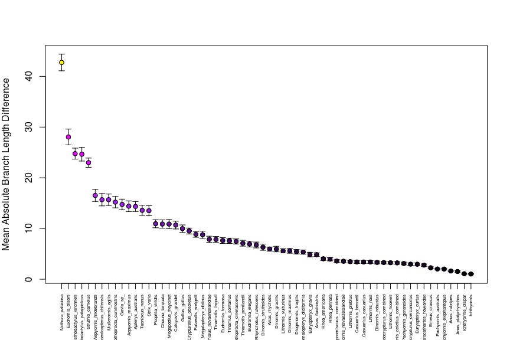

```r
branch.length.diff(multiPhy, multiPhy1)
```

Add a legend showing the five highest values

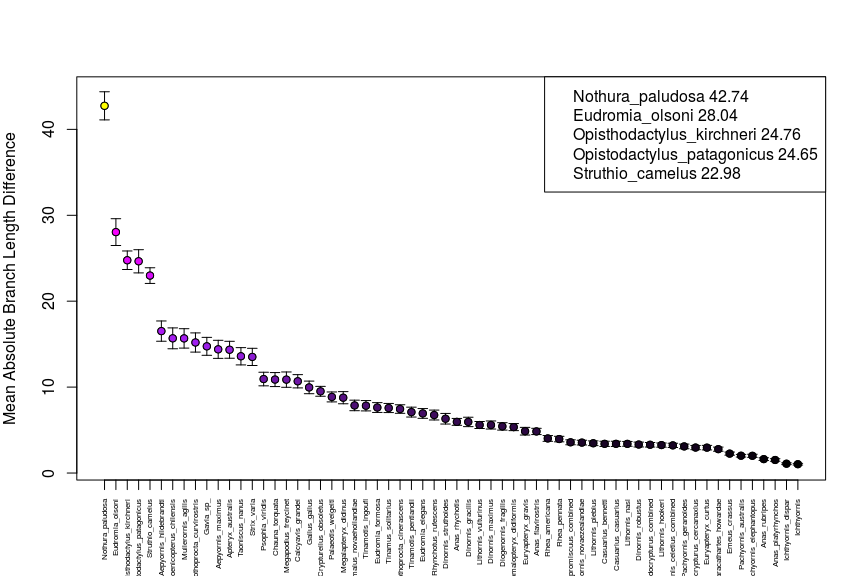

```r
branch.length.diff(multiPhy, multiPhy1, show.top = 5)
```

Alternatively, only plot the five highest values

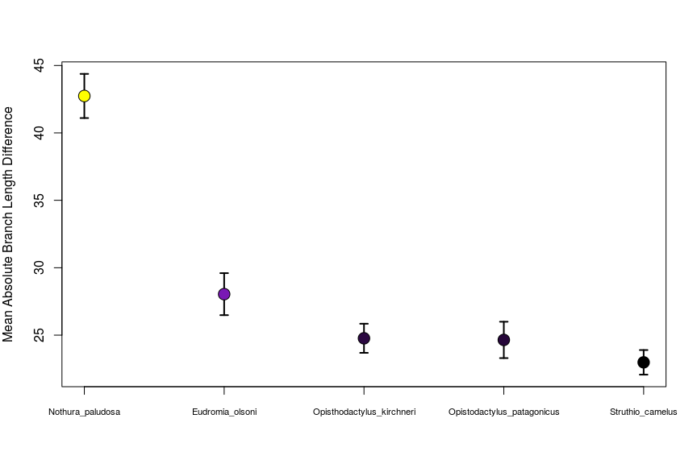

```r
branch.length.diff(multiPhy, multiPhy1, plot.top = 5,
                   pt.cex = 2, bar.width = 2, label.horiz = TRUE, taxon.label.cex = 0.7)
```